# VME Analysis_R manuscript

Felix Klotzsche, Sven Ohl

8 6 2021

## Intro

This file prints relevant statistics and plots of the vMemEcc manuscript. Please note, analyses and plots produced in Python are not included here - but in a separate notebook. The most relevant chunkcs of the source code are included in this file as well. For the full code base, please refer to the [repository on GitHub](https://github.com/eioe/vmemecc).

## Requirements

We ran these analyses using R version 4.1.0 (2021-05-18) (in RStudio 1.4.1717).

## Init workspace

Loads packages, custom functions, custom themes, and data. Data is made availbale in the workspace as data frame `data_behav`.

- **ppid** (chr): subject id (e.g., “VME_S09”)
- **trial_num** (num): index of the trial in the experiment (includes all trials from all blocks; also training) “perception” block: 11-82  
  vSTM block (“experiment”): 93-812
- **block_num** (num): index of the block
- **c_StimN** (num): number of memory items (2 or 4)
- **c_Ecc** (num): stimulus eccentricity (4, 9, 14)
- **c_ResponseCorrect** (logi): correctness of response in this trial
- **c_ResponseTime** (num): RT
- **BlockStyle** (chr): denotes if trial was in “perception” or vSTM (“experiment”) block
- **CDA_amp** (num): avg. CDA amplitude in this trial (see paper for spec. of ROI and time window)
- **PNP_amp** (num): avg. PNP amplitude in this trial (see paper for spec. of ROI and time window)
- **alphapwr_diff_retent** (num): avg. lateralized alpha power in this trial (see paper for spec. of freq. band, ROI and time window)

```r
#--------------------------------------------------------------------------
# Run main script for analysis for:
#  vMemEcc
#--------------------------------------------------------------------------

library(here)
library(knitr)



#--------------------------------------------------------------------------
# Define pathes
path_global         <- here('../..')
path_r_data       <- file.path(path_global, 'Data/DataR')
path_scripts_sven <- file.path(here('Workflow_Sven',
                                    'osf_experiment1',
                                    '_RScripts'))
path_extracted_vars <- file.path(path_global, 'Writing',
                             'Other',
                             'VME_extracted_vars.json')

#--------------------------------------------------------------------------
## load packages
source(here("Utils", "load_packages.R"))
source(here('Utils', 'print_output.R'))
source(file.path(path_scripts_sven,"loadPackages.R"))

#--------------------------------------------------------------------------

#--------------------------------------------------------------------------
## define colors
source(file.path(path_scripts_sven, "loadColors.R"))
#--------------------------------------------------------------------------

#--------------------------------------------------------------------------
## load function to compute confidence intervals
source(file.path(path_scripts_sven,"loadFunctions.R"))
source(file.path(here('Utils', 'load_functions.R')))
#--------------------------------------------------------------------------

#--------------------------------------------------------------------------
## load theme
source(file.path(path_scripts_sven, "loadTheme.R"))
#--------------------------------------------------------------------------

#--------------------------------------------------------------------------
## load data, assign names for columns and define variable type
source(file.path(here('Utils', 'load_data.R')))
#--------------------------------------------------------------------------
```

## Summary stats:

**Extract relevants descriptives about the data set.**

```r
# Total number of experimental trials (720 x n):

n_rej_subs <- 3
print(str_glue("N rejected subjects: {n_rej_subs}"))
```

```
## N rejected subjects: 3
```

```r
n_subs_analyzed <- length(unique(data_behav$ppid))
n_tot_trials <- 720 * (n_subs_analyzed + n_rej_subs)
n_tot_trials_prerej <- 720 * n_subs_analyzed
print(str_glue("Total number of recorded experimental trials (720 x {n_subs_analyzed + n_rej_subs}): {n_tot_trials_prerej}"))
```

[output not shown]

```r
print(str_glue("Total number of experimental trials after subject rejection (720 x {n_subs_analyzed}): {n_tot_trials_prerej}"))
```

```
## Total number of experimental trials after subject rejection (720 x 21): 15120
```

```r
n_tot_trials_postrej <- data_behav %>% filter(BlockStyle == 'experiment') %>%  drop_na() %>% nrow()
print(str_glue("Total number of trials after rejection: {n_tot_trials_postrej}"))
```

```
## Total number of trials after rejection: 13411
```

```r
exp_data <- data_behav %>%
  filter(BlockStyle == 'experiment') %>%
  drop_na()

# Summary remaining trials:
summary_rem_trials_per_sub <- exp_data %>%
  group_by(ppid) %>%
  summarise(n_trials_remaining = n(),
            perc_trials_remaining = n_trials_remaining*100 / 720,
            .groups = "drop")



print(str_glue("Remaining trials per subject (percentage):
           mean: {mean(summary_rem_trials_per_sub$n_trials_remaining)} ({format(mean(summary_rem_trials_per_sub$perc_trials_remaining), digits=3)}%)
           range:  {min(summary_rem_trials_per_sub$n_trials_remaining)} ({format(min(summary_rem_trials_per_sub$perc_trials_remaining), digits=3)}%) - {max(summary_rem_trials_per_sub$n_trials_remaining)} ({format(max(summary_rem_trials_per_sub$perc_trials_remaining), digits=3)}%)\n\n"))
```

```
## Remaining trials per subject (percentage):
##            mean: 638.619047619048 (88.7%)
##            range:  516 (71.7%) - 704 (97.8%)
```

```r
# Summary accuracy overall:
acc_overall <- exp_data %>%
  group_by(ppid) %>%
  summarise(perc_resp_corr = mean(c_ResponseCorrect) * 100,
            .groups = "drop"
            ) %>%
  ungroup() %>%
  select(!ppid) %>%
  summarise_all(list (mean = mean, sd = sd, min = min, max = max))

stats_overall <- list(
  name = "overall",
  printName = "overall",
  levels = c(""),
  stats = acc_overall
)


# Summary per Memory Load:
acc_per_memLoad <- exp_data %>%
  group_by(ppid, c_StimN) %>%
  summarise(perc_resp_corr = mean(c_ResponseCorrect) * 100,
            .groups = "drop") %>%
  pivot_wider(names_from = c_StimN,
              values_from = perc_resp_corr,
              names_prefix = "StimN_") %>%
  ungroup() %>%
  select(!ppid) %>%
  summarise_all(list (mean = mean, sd = sd, min = min, max = max))

stats_memLoad <- list(
  name = "StimN",
  printName = "memLoad",
  levels = str_c("StimN_", unique(exp_data$c_StimN), '_'),
  stats = acc_per_memLoad
)


# Summary per Ecc:
acc_per_ecc <- exp_data %>%
  group_by(ppid, c_Ecc) %>%
  summarise(perc_resp_corr = mean(c_ResponseCorrect) * 100,
            .groups = "drop") %>%
  pivot_wider(names_from = c_Ecc,
              values_from = perc_resp_corr,
              names_prefix = "Ecc_") %>%
  ungroup() %>%
  select(!ppid) %>%
  summarise_all(list (mean = mean, sd = sd, min = min, max = max))

stats_ecc <- list(
  name = "ecc",
  printName = "Ecc",
  levels = str_c("Ecc_", sort(unique(exp_data$c_Ecc)), '_'),
  stats = acc_per_ecc
)


for (tmp in list(stats_overall, stats_memLoad, stats_ecc)) {

  print(str_glue("Memory performance ({if_else(str_detect(tmp$printName, 'overall'), '', 'by ')}{tmp$printName}):\n"))
  for (lvl in tmp$levels) {
    if (length(tmp$levels) > 1) print(str_glue("{tmp$printName} == {parse_number(lvl)}:"))
    print(str_glue("    mean (%): {tmp$stats[str_c(lvl, 'mean')]}"))
    print(str_glue("    SD   (%): {tmp$stats[str_c(lvl, 'sd')]}"))
    print(str_glue("    min  (%): {tmp$stats[str_c(lvl, 'min')]}"))
    print(str_glue("    max  (%): {tmp$stats[str_c(lvl, 'max')]}"))
  }
  cat("\n\n")
}
```

```
## Memory performance (overall):
##     mean (%): 85.4286290452115
##     SD   (%): 4.16276799592646
##     min  (%): 78.8617886178862
##     max  (%): 92.5925925925926
##
##
## Memory performance (by memLoad):
## memLoad == 2:
##     mean (%): 94.5819608844091
##     SD   (%): 2.49135704388167
##     min  (%): 89.149560117302
##     max  (%): 98.4472049689441
## memLoad == 4:
##     mean (%): 76.1846674842646
##     SD   (%): 6.7447448708311
##     min  (%): 66.3366336633663
##     max  (%): 88.0239520958084
##
##
## Memory performance (by Ecc):
## Ecc == 4:
##     mean (%): 85.7423902534488
##     SD   (%): 4.6285187298247
##     min  (%): 75
##     max  (%): 93.4883720930233
## Ecc == 9:
##     mean (%): 86.2074104343587
##     SD   (%): 4.50509282230014
##     min  (%): 77.8301886792453
##     max  (%): 94.7826086956522
## Ecc == 14:
##     mean (%): 84.3572909836843
##     SD   (%): 4.55371342304476
##     min  (%): 76.6169154228856
##     max  (%): 91.8367346938776
```

```r
extract_var("n_rej_subs", n_rej_subs, exp_format = "%i")
extract_var("n_tot_trials_prerej_allsubs", 720 * (n_subs_analyzed + n_rej_subs), exp_format = "%i")
extract_var("n_subs_analyzed", n_subs_analyzed, exp_format = "%i")
extract_var("n_tot_trials_prerej", n_tot_trials_prerej, exp_format = "%i")
extract_var("n_tot_trials_postrej", n_tot_trials_postrej, exp_format = "%i")
extract_var("n_tot_trials_prerej", n_tot_trials_prerej, exp_format = "%i")
extract_var("avg_n_trials_per_sub_postrej", mean(summary_rem_trials_per_sub$n_trials_remaining), exp_format="%.2f")
extract_var("min_n_trials_per_sub_postrej", min(summary_rem_trials_per_sub$n_trials_remaining), exp_format="%i")
extract_var("max_n_trials_per_sub_postrej", max(summary_rem_trials_per_sub$n_trials_remaining), exp_format="%i")
extract_var("min_perc_trials_per_sub_postrej", min(summary_rem_trials_per_sub$perc_trials_remaining), exp_format="%.2f")
extract_var("max_perc_trials_per_sub_postrej", max(summary_rem_trials_per_sub$perc_trials_remaining), exp_format="%.2f")
for (tmp in list(stats_overall, stats_memLoad, stats_ecc)) {
  for (lvl in tmp$levels) {
    for (stat in c("mean", "sd", "min", "max")) {
      extract_var(str_glue("mem_acc_{lvl}{stat}"), tmp$stats[str_c(lvl, stat)], exp_format="%.2f")
    }
  }
}
```

## Analysis 01:

**Is there an effect of workload or eccentricity on performance in the VSTM task and in the perception task?**

### VSTM Task:

```r
# VSTM task:
func_analysis_01('experiment')
```

```
##
## ###########################
## Summary ANOVA
## task: experiment
## ###########################
##
##
## Error: ppid
##           Df Sum Sq Mean Sq F value Pr(>F)
## Residuals 20 0.2169 0.01085
##
## Error: ppid:c_StimN
##           Df Sum Sq Mean Sq F value   Pr(>F)
## c_StimN    1 1.0507  1.0507   191.8 1.04e-11 ***
## Residuals 20 0.1096  0.0055
## ---
## Signif. codes:  0 '***' 0.001 '**' 0.01 '*' 0.05 '.' 0.1 ' ' 1
##
## Error: ppid:c_Ecc
##           Df   Sum Sq  Mean Sq F value Pr(>F)
## c_Ecc      1 0.004696 0.004696   5.302 0.0322 *
## Residuals 20 0.017712 0.000886
## ---
## Signif. codes:  0 '***' 0.001 '**' 0.01 '*' 0.05 '.' 0.1 ' ' 1
##
## Error: ppid:c_StimN:c_Ecc
##               Df   Sum Sq   Mean Sq F value Pr(>F)
## c_StimN:c_Ecc  1 0.000675 0.0006751   0.642  0.432
## Residuals     20 0.021021 0.0010510
##
## Error: Within
##           Df Sum Sq  Mean Sq F value Pr(>F)
## Residuals 42 0.0433 0.001031
##
## ###########################
## Results post-hoc t test
## task: experiment
## ###########################
##
## # A tibble: 3 x 10
##   .y.     group1 group2    n1    n2 statistic    df     p p.adj p.adj.signif
## * <chr>   <chr>  <chr>  <int> <int>     <dbl> <dbl> <dbl> <dbl> <chr>
## 1 meanAcc 4      9         21    21    -0.692    20 0.497 1     ns
## 2 meanAcc 4      14        21    21     2.30     20 0.032 0.097 ns
## 3 meanAcc 9      14        21    21     3.26     20 0.004 0.012 *
```

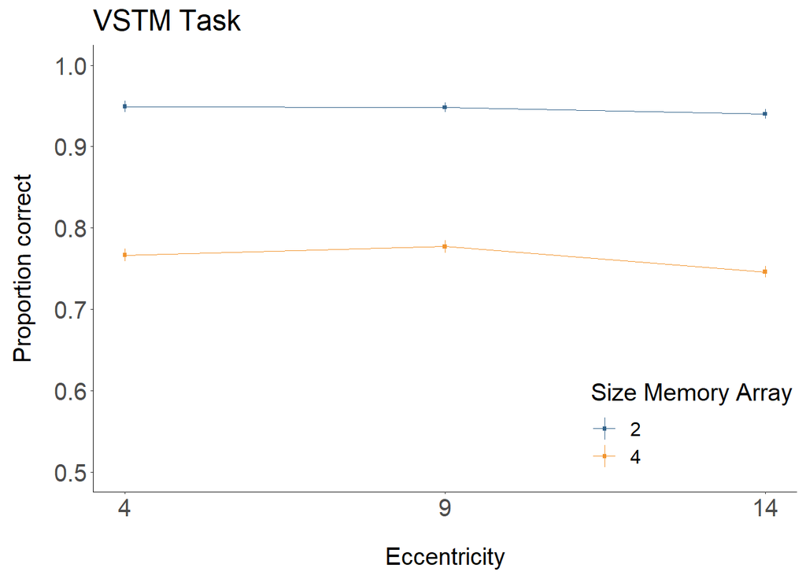

*show source:*

```r
func_analysis_01 <-
function (condition)
{
    c1.aov <- data_behav %>% filter(BlockStyle == condition) %>%
        group_by(ppid, c_StimN, c_Ecc) %>% summarise(meanAcc = mean(c_ResponseCorrect)) %>%
        ungroup() %>% select("meanAcc", "c_StimN", "c_Ecc", "ppid")
    c1.reduced <- c1.aov %>% pivot_wider(names_from = c(c_StimN,
        c_Ecc), values_from = meanAcc, names_prefix = "cond_") %>%
        select(., contains("cond_"))
    ci_cm <- cm.ci(data.frame = c1.reduced, conf.level = 2 *
        (pnorm(1, 0, 1) - 0.5), difference = TRUE)
    aov.srt <- aov(meanAcc ~ c_StimN * c_Ecc + Error(ppid/(c_StimN *
        c_Ecc)), data = c1.aov)
    print_header(str_c("Summary ANOVA \ntask: ", condition))
    print(summary(aov.srt))
    res_ttest <- c1.aov %>% group_by(ppid, c_Ecc) %>% summarise(meanAcc = mean(meanAcc)) %>%
        ungroup() %>% pairwise_t_test(meanAcc ~ c_Ecc, paired = TRUE,
        p.adjust.method = "bonferroni")
    print_header(str_c("Results post-hoc t test\ntask: ", condition))
    print(res_ttest)
    c1.plt <- c1.aov %>% group_by(c_StimN, c_Ecc) %>% summarise(meanAcc = mean(meanAcc)) %>%
        mutate(cond = str_c("cond", c_StimN, c_Ecc, sep = "_"),
            c_Ecc = as.numeric(as.character(c_Ecc))) %>% left_join(as_tibble(ci_cm) %>%
        add_column(cond = rownames(ci_cm)), by = "cond")
    txt_title <- ifelse(condition == "perception", "Perceptual Task",
        "VSTM Task")
    figa <- ggplot(c1.plt, aes(x = c_Ecc, y = meanAcc, ymin = lower,
        ymax = upper, colour = as_factor(c_StimN)))
    figa <- figa + geom_line(size = 0.23584910000000001) + geom_point(shape = 15,
        size = 0.80000000000000004)
    figa <- figa + scale_colour_manual(values = c(defblue, deforange,
        defgrey))
    figa <- figa + scale_fill_manual(values = c(defblue, deforange,
        defgrey))
    figa <- figa + geom_linerange(size = 0.23584910000000001)
    figa <- figa + scale_x_continuous(breaks = c(4, 9, 14))
    figa <- figa + scale_y_continuous(limits = c(0.5, 1))
    figa <- figa + mytheme
    figa <- figa + ylab("Proportion correct") + xlab("Eccentricity")
    figa <- figa + labs(title = txt_title, color = "Size Memory Array")
    figa <- figa + theme(legend.position = c(0.84999999999999998,
        0.14999999999999999))
    figa
}
```

### Perception task:

```r
# perceptual Change Detection Task:
func_analysis_01('perception')
```

```
##
## ###########################
## Summary ANOVA
## task: perception
## ###########################
##
##
## Error: ppid
##           Df Sum Sq  Mean Sq F value Pr(>F)
## Residuals 20 0.1187 0.005934
##
## Error: ppid:c_StimN
##           Df  Sum Sq  Mean Sq F value Pr(>F)
## c_StimN    1 0.00931 0.009314   1.877  0.186
## Residuals 20 0.09922 0.004961
##
## Error: ppid:c_Ecc
##           Df  Sum Sq Mean Sq F value   Pr(>F)
## c_Ecc      1 0.08418 0.08418   18.74 0.000326 ***
## Residuals 20 0.08982 0.00449
## ---
## Signif. codes:  0 '***' 0.001 '**' 0.01 '*' 0.05 '.' 0.1 ' ' 1
##
## Error: ppid:c_StimN:c_Ecc
##               Df  Sum Sq  Mean Sq F value Pr(>F)
## c_StimN:c_Ecc  1 0.00872 0.008724   2.327  0.143
## Residuals     20 0.07500 0.003750
##
## Error: Within
##           Df Sum Sq  Mean Sq F value Pr(>F)
## Residuals 42 0.1802 0.004291
##
## ###########################
## Results post-hoc t test
## task: perception
## ###########################
##
## # A tibble: 3 x 10
##   .y.    group1 group2    n1    n2 statistic    df        p   p.adj p.adj.signif
## * <chr>  <chr>  <chr>  <int> <int>     <dbl> <dbl>    <dbl>   <dbl> <chr>
## 1 meanA~ 4      9         21    21     0.163    20 0.872    1   e+0 ns
## 2 meanA~ 4      14        21    21     4.33     20 0.000326 9.78e-4 ***
## 3 meanA~ 9      14        21    21     4.23     20 0.000408 1   e-3 **
```

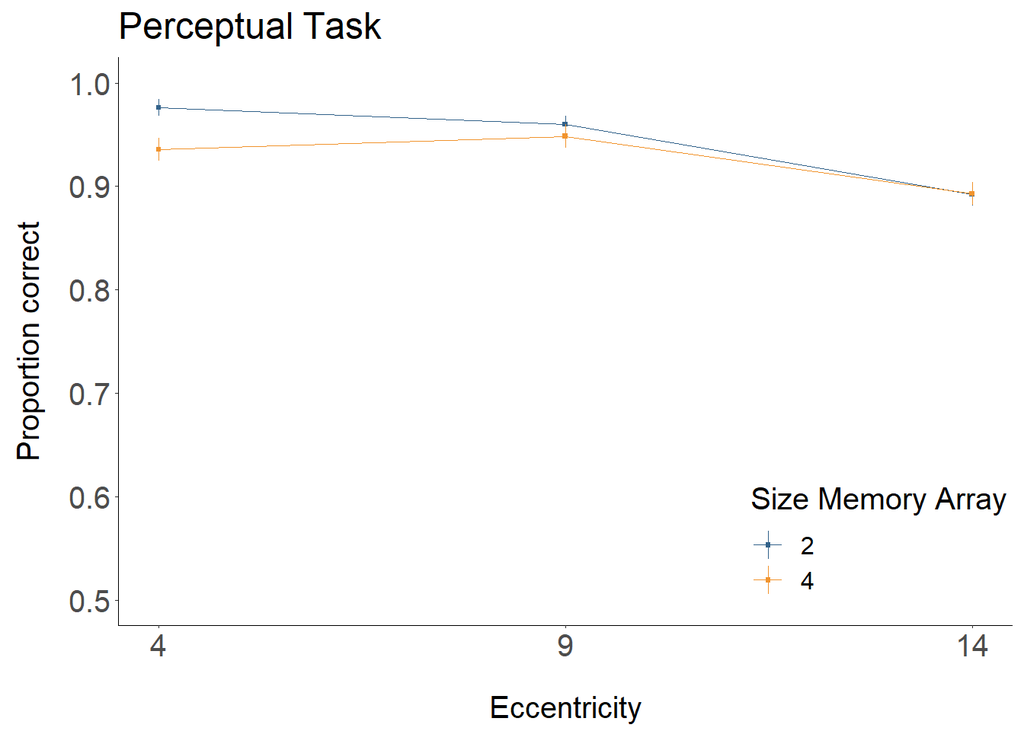

```r
func_analysis_01 <-
function (condition)
{
    c1.aov <- data_behav %>% filter(BlockStyle == condition) %>%
        group_by(ppid, c_StimN, c_Ecc) %>% summarise(meanAcc = mean(c_ResponseCorrect)) %>%
        ungroup() %>% select("meanAcc", "c_StimN", "c_Ecc", "ppid")
    c1.reduced <- c1.aov %>% pivot_wider(names_from = c(c_StimN,
        c_Ecc), values_from = meanAcc, names_prefix = "cond_") %>%
        select(., contains("cond_"))
    ci_cm <- cm.ci(data.frame = c1.reduced, conf.level = 2 *
        (pnorm(1, 0, 1) - 0.5), difference = TRUE)
    aov.srt <- aov(meanAcc ~ c_StimN * c_Ecc + Error(ppid/(c_StimN *
        c_Ecc)), data = c1.aov)
    print_header(str_c("Summary ANOVA \ntask: ", condition))
    print(summary(aov.srt))
    res_ttest <- c1.aov %>% group_by(ppid, c_Ecc) %>% summarise(meanAcc = mean(meanAcc)) %>%
        ungroup() %>% pairwise_t_test(meanAcc ~ c_Ecc, paired = TRUE,
        p.adjust.method = "bonferroni")
    print_header(str_c("Results post-hoc t test\ntask: ", condition))
    print(res_ttest)
    c1.plt <- c1.aov %>% group_by(c_StimN, c_Ecc) %>% summarise(meanAcc = mean(meanAcc)) %>%
        mutate(cond = str_c("cond", c_StimN, c_Ecc, sep = "_"),
            c_Ecc = as.numeric(as.character(c_Ecc))) %>% left_join(as_tibble(ci_cm) %>%
        add_column(cond = rownames(ci_cm)), by = "cond")
    txt_title <- ifelse(condition == "perception", "Perceptual Task",
        "VSTM Task")
    figa <- ggplot(c1.plt, aes(x = c_Ecc, y = meanAcc, ymin = lower,
        ymax = upper, colour = as_factor(c_StimN)))
    figa <- figa + geom_line(size = 0.23584910000000001) + geom_point(shape = 15,
        size = 0.80000000000000004)
    figa <- figa + scale_colour_manual(values = c(defblue, deforange,
        defgrey))
    figa <- figa + scale_fill_manual(values = c(defblue, deforange,
        defgrey))
    figa <- figa + geom_linerange(size = 0.23584910000000001)
    figa <- figa + scale_x_continuous(breaks = c(4, 9, 14))
    figa <- figa + scale_y_continuous(limits = c(0.5, 1))
    figa <- figa + mytheme
    figa <- figa + ylab("Proportion correct") + xlab("Eccentricity")
    figa <- figa + labs(title = txt_title, color = "Size Memory Array")
    figa <- figa + theme(legend.position = c(0.84999999999999998,
        0.14999999999999999))
    figa
}
```

## Analysis 01 - supplement:

**Is there an effect of workload or eccentricity on RT in the VSTM task and in the perception task?**  
This analysis was only conducted to exclude that a speed-acc trade-off is taking place. As we did not instruct participants to answer as fast as possible and due to imprecise temporal measurements of RTs with the VR hard- and software, we do not report this analysis in the paper.

### VSTM Task:

```r
# VSTM task:
func_analysis_03('experiment')
```

```
##
## ###########################
## Summary ANOVA
## task: experiment
## ###########################
##
##
## Error: ppid
##           Df Sum Sq Mean Sq F value Pr(>F)
## Residuals 20  3.279   0.164
##
## Error: ppid:c_StimN
##           Df Sum Sq Mean Sq F value   Pr(>F)
## c_StimN    1 0.6394  0.6394   56.82 2.89e-07 ***
## Residuals 20 0.2251  0.0113
## ---
## Signif. codes:  0 '***' 0.001 '**' 0.01 '*' 0.05 '.' 0.1 ' ' 1
##
## Error: ppid:c_Ecc
##           Df  Sum Sq Mean Sq F value   Pr(>F)
## c_Ecc      1 0.04105 0.04105   14.94 0.000964 ***
## Residuals 20 0.05496 0.00275
## ---
## Signif. codes:  0 '***' 0.001 '**' 0.01 '*' 0.05 '.' 0.1 ' ' 1
##
## Error: ppid:c_StimN:c_Ecc
##               Df  Sum Sq   Mean Sq F value Pr(>F)
## c_StimN:c_Ecc  1 0.00047 0.0004709   0.271  0.608
## Residuals     20 0.03476 0.0017380
##
## Error: Within
##           Df  Sum Sq  Mean Sq F value Pr(>F)
## Residuals 42 0.04256 0.001013
##
## ###########################
## Results post-hoc t test
## task: experiment
## ###########################
##
## # A tibble: 3 x 10
##   .y.    group1 group2    n1    n2 statistic    df        p   p.adj p.adj.signif
## * <chr>  <chr>  <chr>  <int> <int>     <dbl> <dbl>    <dbl>   <dbl> <chr>
## 1 meanRT 4      9         21    21     -1.55    20  1.36e-1 4.08e-1 ns
## 2 meanRT 4      14        21    21     -3.87    20  9.64e-4 3   e-3 **
## 3 meanRT 9      14        21    21     -4.92    20  8.18e-5 2.45e-4 ***
```

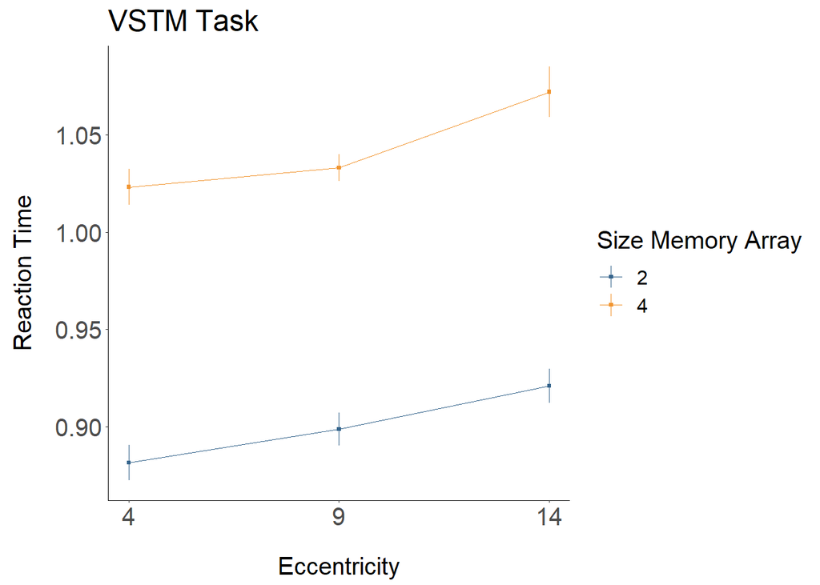

### Perception Task:

```r
# perceptual Change Detection Task:
func_analysis_03('perception')
```

```
##
## ###########################
## Summary ANOVA
## task: perception
## ###########################
##
##
## Error: ppid
##           Df Sum Sq Mean Sq F value Pr(>F)
## Residuals 20  5.867  0.2933
##
## Error: ppid:c_StimN
##           Df Sum Sq  Mean Sq F value Pr(>F)
## c_StimN    1 0.0088 0.008824   0.385  0.542
## Residuals 20 0.4580 0.022899
##
## Error: ppid:c_Ecc
##           Df  Sum Sq Mean Sq F value Pr(>F)
## c_Ecc      1 0.03223 0.03223   2.523  0.128
## Residuals 20 0.25553 0.01278
##
## Error: ppid:c_StimN:c_Ecc
##               Df  Sum Sq  Mean Sq F value Pr(>F)
## c_StimN:c_Ecc  1 0.00002 0.000024   0.005  0.944
## Residuals     20 0.09676 0.004838
##
## Error: Within
##           Df Sum Sq  Mean Sq F value Pr(>F)
## Residuals 42 0.3214 0.007651
##
## ###########################
## Results post-hoc t test
## task: perception
## ###########################
##
## # A tibble: 3 x 10
##   .y.    group1 group2    n1    n2 statistic    df     p p.adj p.adj.signif
## * <chr>  <chr>  <chr>  <int> <int>     <dbl> <dbl> <dbl> <dbl> <chr>
## 1 meanRT 4      9         21    21      1.14    20 0.267 0.801 ns
## 2 meanRT 4      14        21    21     -1.59    20 0.128 0.384 ns
## 3 meanRT 9      14        21    21     -3.40    20 0.003 0.009 **
```

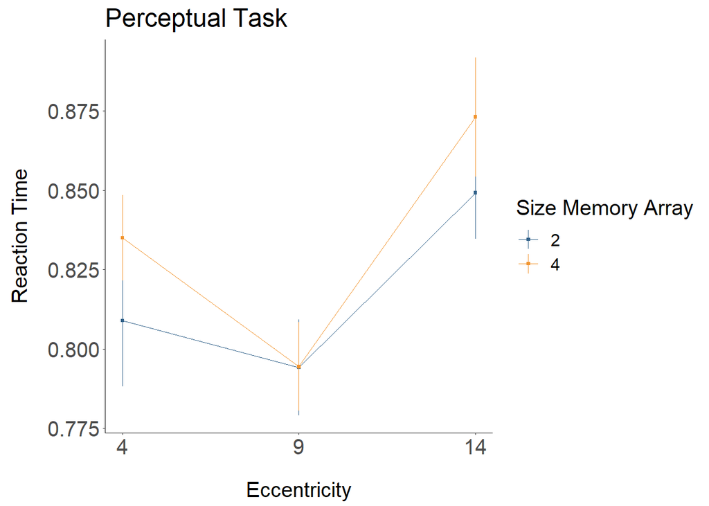

## Analysis 02:

**Is there an effect of workload or eccentricity on mean CDA amplitude in the VSTM task?**

### CDA amplitude (rmANOVA):

```r
func_analysis_05()
```

```
##
## ###########################
## Summary ANOVA
## task: experiment
## ###########################
##
##
## Error: ppid
##           Df Sum Sq Mean Sq F value Pr(>F)
## Residuals 20  42.28   2.114
##
## Error: ppid:c_StimN
##           Df Sum Sq Mean Sq F value   Pr(>F)
## c_StimN    1  4.039   4.039   17.27 0.000489 ***
## Residuals 20  4.678   0.234
## ---
## Signif. codes:  0 '***' 0.001 '**' 0.01 '*' 0.05 '.' 0.1 ' ' 1
##
## Error: ppid:c_Ecc
##           Df Sum Sq Mean Sq F value Pr(>F)
## c_Ecc      2  0.233  0.1168   0.735  0.486
## Residuals 40  6.353  0.1588
##
## Error: ppid:c_StimN:c_Ecc
##               Df Sum Sq Mean Sq F value Pr(>F)
## c_StimN:c_Ecc  2  0.450  0.2250   1.941  0.157
## Residuals     40  4.636  0.1159
##
## ###########################
## Results post-hoc t test
## task: experiment
## ###########################
##
## # A tibble: 3 x 10
##   .y.     group1 group2    n1    n2 statistic    df     p p.adj p.adj.signif
## * <chr>   <chr>  <chr>  <int> <int>     <dbl> <dbl> <dbl> <dbl> <chr>
## 1 meanCDA 4      9         21    21    -0.470    20 0.644 1     ns
## 2 meanCDA 4      14        21    21    -1.23     20 0.234 0.702 ns
## 3 meanCDA 9      14        21    21    -0.766    20 0.453 1     ns
```

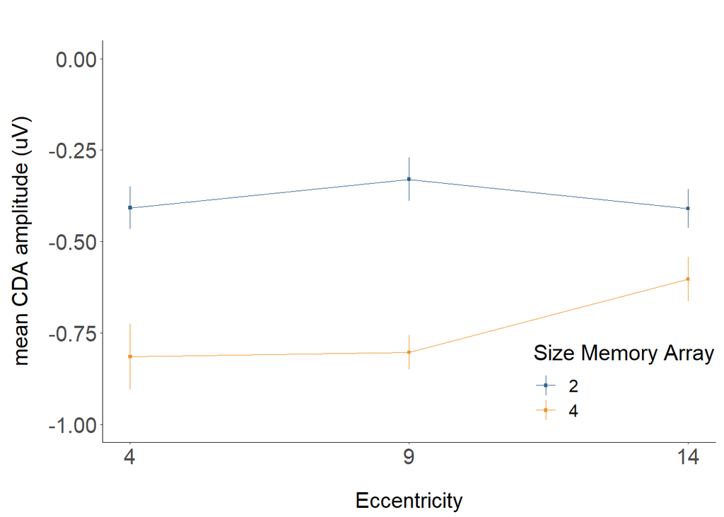

*show source:*

```r
func_analysis_05 <-
function ()
{
    condition <- "experiment"
    c1.aov <- data_behav %>% mutate(c_Ecc = as_factor(c_Ecc)) %>%
        filter(BlockStyle == condition) %>% group_by(ppid, c_StimN,
        c_Ecc) %>% summarise(meanCDA = mean(CDA_amp, na.rm = T)) %>%
        ungroup() %>% select("meanCDA", "c_StimN", "c_Ecc", "ppid")
    c1.reduced <- c1.aov %>% pivot_wider(names_from = c(c_StimN,
        c_Ecc), values_from = meanCDA, names_prefix = "cond_") %>%
        select(., contains("cond_")) %>% drop_na()
    ci_cm <- cm.ci(data.frame = c1.reduced, conf.level = 2 *
        (pnorm(1, 0, 1) - 0.5), difference = TRUE)
    aov.srt <- aov(meanCDA ~ c_StimN * c_Ecc + Error(ppid/(c_StimN *
        c_Ecc)), data = c1.aov)
    print_header(str_c("Summary ANOVA \ntask: ", condition))
    print(summary(aov.srt))
    res_ttest <- c1.aov %>% group_by(ppid, c_Ecc) %>% summarise(meanCDA = mean(meanCDA)) %>%
        ungroup() %>% pairwise_t_test(meanCDA ~ c_Ecc, paired = TRUE,
        p.adjust.method = "bonferroni")
    print_header(str_c("Results post-hoc t test\ntask: ", condition))
    print(res_ttest)
    c1.plt <- c1.aov %>% group_by(c_StimN, c_Ecc) %>% summarise(meanCDA = mean(meanCDA,
        na.rm = T)) %>% mutate(cond = str_c("cond", c_StimN,
        c_Ecc, sep = "_"), c_Ecc = as.numeric(as.character(c_Ecc))) %>%
        left_join(as_tibble(ci_cm) %>% add_column(cond = rownames(ci_cm)),
            by = "cond")
    txt_title <- ""
    figa <- ggplot(c1.plt, aes(x = c_Ecc, y = meanCDA, ymin = lower,
        ymax = upper, colour = as_factor(c_StimN)))
    figa <- figa + geom_line(size = 0.23584910000000001) + geom_point(shape = 15,
        size = 0.80000000000000004)
    figa <- figa + scale_colour_manual(values = c(col_LoadLow,
        col_LoadHigh))
    figa <- figa + scale_fill_manual(values = c(defblue, deforange,
        defgrey))
    figa <- figa + geom_linerange(size = 0.23584910000000001)
    figa <- figa + scale_x_continuous(breaks = c(4, 9, 14))
    figa <- figa + scale_y_continuous(limits = c(-1, 0))
    figa <- figa + mytheme
    figa <- figa + ylab("mean CDA amplitude (uV)") + xlab("Eccentricity")
    figa <- figa + labs(title = txt_title, color = "Size Memory Array")
    figa <- figa + theme(legend.position = c(0.84999999999999998,
        0.14999999999999999))
    figa
}
```

### Analysis 02 - Supplement 1: CDA amplitude (lmer):

A multilevel model confirms the results of the rmANOVA:

```r
func_analysis_07('experiment', dep_variable = 'CDA_amp')
```

```
##
## ###########################
## Summary glmer
## CDA_amp ~ MemLoad * Eccentricity
## task: experiment
## ###########################
```

```
## Linear mixed model fit by REML. t-tests use Satterthwaite's method [
## lmerModLmerTest]
## Formula: CDA_amp ~ load_contrast * c_Ecc + (1 | ppid)
##    Data: data_filtered
##
## REML criterion at convergence: 77632.4
##
## Scaled residuals:
##     Min      1Q  Median      3Q     Max
## -5.0972 -0.6469  0.0033  0.6417  5.5575
##
## Random effects:
##  Groups   Name        Variance Std.Dev.
##  ppid     (Intercept)  0.3275  0.5723
##  Residual             15.2156  3.9007
## Number of obs: 13950, groups:  ppid, 21
##
## Fixed effects:
##                        Estimate Std. Error         df t value Pr(>|t|)
## (Intercept)          -8.001e-01  1.488e-01  3.529e+01  -5.376 5.01e-06 ***
## load_contrast         4.751e-01  1.143e-01  1.392e+04   4.155 3.27e-05 ***
## c_Ecc1               -3.326e-02  1.154e-01  1.392e+04  -0.288   0.7733
## c_Ecc3                1.913e-01  1.139e-01  1.392e+04   1.680   0.0929 .
## load_contrast:c_Ecc1 -4.026e-02  1.628e-01  1.392e+04  -0.247   0.8046
## load_contrast:c_Ecc3 -2.747e-01  1.608e-01  1.392e+04  -1.708   0.0877 .
## ---
## Signif. codes:  0 '***' 0.001 '**' 0.01 '*' 0.05 '.' 0.1 ' ' 1
##
## Correlation of Fixed Effects:
##             (Intr) ld_cnt c_Ecc1 c_Ecc3 l_:_E1
## load_cntrst -0.385
## c_Ecc1      -0.381  0.496
## c_Ecc3      -0.387  0.503  0.498
## ld_cntr:_E1  0.270 -0.703 -0.709 -0.353
## ld_cntr:_E3  0.274 -0.711 -0.353 -0.708  0.499
```

*show source:*

```r
func_analysis_07 <-
function (condition, dep_variable)
{
    condition <- "experiment"
    data_filtered <- data_behav %>% filter(BlockStyle == condition) %>%
        select(ppid, c_StimN, c_Ecc, CDA_amp) %>% mutate(c_Ecc = as_factor(c_Ecc))
    contrasts(data_filtered$c_Ecc) <- contr.treatment(3, base = 2)
    data_filtered$load_contrast <- ifelse(data_filtered$c_StimN ==
        2, 1, 0)
    glmer.family = ifelse(dep_variable == "c_ResponseCorrect",
        "binomial", "gaussian")
    m1 <- lmer(CDA_amp ~ load_contrast * c_Ecc + (1 | ppid),
        data = data_filtered)
    print_header(str_c("Summary glmer\n", dep_variable, " ~ MemLoad * Eccentricity\n",
        "task: ", condition))
    summary(m1)
}
```

### Analysis 02 - Supplement 2: PNP amplitude (rmANOVA):

Testing the effects of *memory load* and *eccentricity* on the mean **PNP amplitude** (see [Papaioannou & Luck, 2020](https://onlinelibrary.wiley.com/doi/abs/10.1111/psyp.13532))

```r
func_analysis_09()
```

```
##
## ###########################
## Summary ANOVA
## task: experiment
## ###########################
##
##
## Error: ppid
##           Df Sum Sq Mean Sq F value Pr(>F)
## Residuals 20  34.39    1.72
##
## Error: ppid:c_StimN
##           Df Sum Sq Mean Sq F value Pr(>F)
## c_StimN    1 0.0001 0.00007   0.001  0.981
## Residuals 20 2.3055 0.11527
##
## Error: ppid:c_Ecc
##           Df Sum Sq Mean Sq F value   Pr(>F)
## c_Ecc      2  5.567  2.7834   14.28 2.09e-05 ***
## Residuals 40  7.797  0.1949
## ---
## Signif. codes:  0 '***' 0.001 '**' 0.01 '*' 0.05 '.' 0.1 ' ' 1
##
## Error: ppid:c_StimN:c_Ecc
##               Df Sum Sq Mean Sq F value Pr(>F)
## c_StimN:c_Ecc  2  0.277 0.13842   1.448  0.247
## Residuals     40  3.823 0.09557
##
## ###########################
## Results post-hoc t test
## task: experiment
## ###########################
##
## # A tibble: 3 x 10
##   .y.    group1 group2    n1    n2 statistic    df        p   p.adj p.adj.signif
## * <chr>  <chr>  <chr>  <int> <int>     <dbl> <dbl>    <dbl>   <dbl> <chr>
## 1 meanP~ 4      9         21    21     -3.44    20 0.003    8   e-3 **
## 2 meanP~ 4      14        21    21     -4.53    20 0.000203 6.09e-4 ***
## 3 meanP~ 9      14        21    21     -2.14    20 0.044    1.34e-1 ns
```

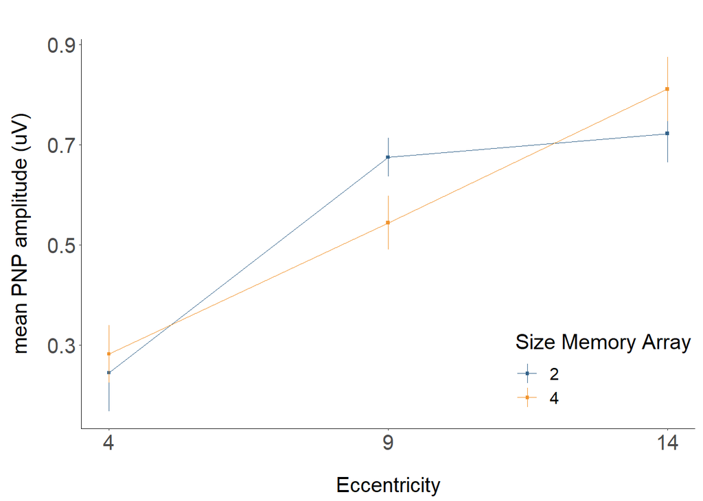

## Analysis 03:

**Is there an effect of workload or eccentricity on mean lateralized alpha power in the VSTM task?** See paper for specifics of parameters re. frequency band, ROI, and time window that were used to calculate mean lateralized power (power **contralaterally - ipsilaterally**)

### lat. alpha power (rmANOVA):

```r
func_analysis_06()
```

```
##
## ###########################
## Summary ANOVA
## task: experiment
## ###########################
##
##
## Error: ppid
##           Df    Sum Sq   Mean Sq F value Pr(>F)
## Residuals 20 8.265e-06 4.133e-07
##
## Error: ppid:c_StimN
##           Df    Sum Sq   Mean Sq F value Pr(>F)
## c_StimN    1 2.460e-08 2.456e-08   0.484  0.495
## Residuals 20 1.015e-06 5.074e-08
##
## Error: ppid:c_Ecc
##           Df    Sum Sq   Mean Sq F value Pr(>F)
## c_Ecc      1 1.150e-08 1.148e-08   0.157  0.696
## Residuals 20 1.464e-06 7.317e-08
##
## Error: ppid:c_StimN:c_Ecc
##               Df    Sum Sq   Mean Sq F value Pr(>F)
## c_StimN:c_Ecc  1 1.470e-07 1.470e-07   1.951  0.178
## Residuals     20 1.507e-06 7.533e-08
##
## Error: Within
##           Df    Sum Sq   Mean Sq F value Pr(>F)
## Residuals 42 3.354e-06 7.985e-08
##
## ###########################
## Results post-hoc t test
## task: experiment
## ###########################
##
## # A tibble: 3 x 10
##   .y.       group1 group2    n1    n2 statistic    df     p p.adj p.adj.signif
## * <chr>     <chr>  <chr>  <int> <int>     <dbl> <dbl> <dbl> <dbl> <chr>
## 1 meanAlpha 4      9         21    21    -1.68     20 0.109 0.327 ns
## 2 meanAlpha 4      14        21    21    -0.396    20 0.696 1     ns
## 3 meanAlpha 9      14        21    21     0.604    20 0.553 1     ns
```

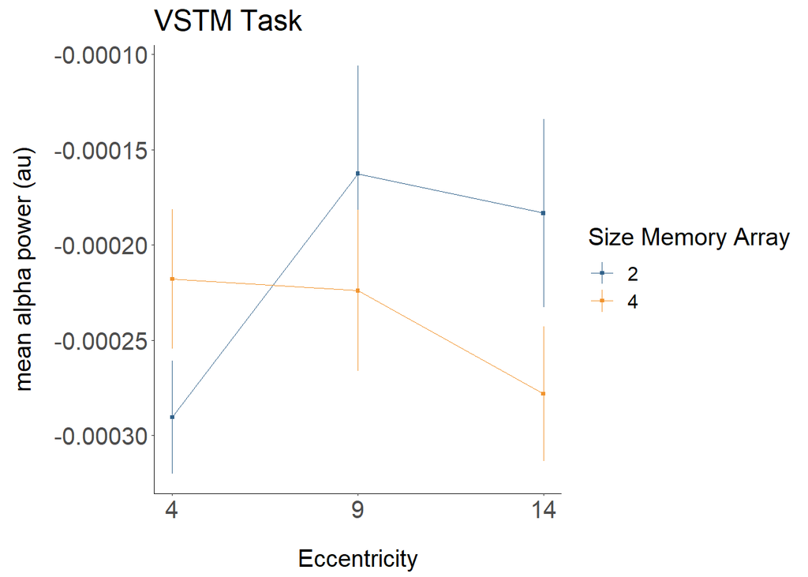

*show source:*

```r
func_analysis_06 <-
function ()
{
    condition <- "experiment"
    c1.aov <- data_behav %>% filter(BlockStyle == "experiment") %>%
        group_by(ppid, c_StimN, c_Ecc) %>% summarise(meanAlpha = mean(alphapwr_diff_retent,
        na.rm = TRUE)) %>% ungroup() %>% select("meanAlpha",
        "c_StimN", "c_Ecc", "ppid")
    c1.reduced <- c1.aov %>% pivot_wider(names_from = c(c_StimN,
        c_Ecc), values_from = meanAlpha, names_prefix = "cond_") %>%
        select(., contains("cond_"))
    ci_cm <- cm.ci(data.frame = c1.reduced, conf.level = 2 *
        (pnorm(1, 0, 1) - 0.5), difference = TRUE)
    aov.srt <- aov(meanAlpha ~ c_StimN * c_Ecc + Error(ppid/(c_StimN *
        c_Ecc)), data = c1.aov)
    print_header(str_c("Summary ANOVA \ntask: ", condition))
    print(summary(aov.srt))
    res_ttest <- c1.aov %>% group_by(ppid, c_Ecc) %>% summarise(meanAlpha = mean(meanAlpha)) %>%
        ungroup() %>% pairwise_t_test(meanAlpha ~ c_Ecc, paired = TRUE,
        p.adjust.method = "bonferroni")
    print_header(str_c("Results post-hoc t test\ntask: ", condition))
    print(res_ttest)
    c1.plt <- c1.aov %>% group_by(c_StimN, c_Ecc) %>% summarise(meanAlpha = mean(meanAlpha)) %>%
        mutate(cond = str_c("cond", c_StimN, c_Ecc, sep = "_"),
            c_Ecc = as.numeric(as.character(c_Ecc))) %>% left_join(as_tibble(ci_cm) %>%
        add_column(cond = rownames(ci_cm)), by = "cond")
    txt_title <- ifelse(condition == "perception", "Perceptual Task",
        "VSTM Task")
    figa <- ggplot(c1.plt, aes(x = c_Ecc, y = meanAlpha, ymin = lower,
        ymax = upper, colour = as_factor(c_StimN)))
    figa <- figa + geom_line(size = 0.23584910000000001) + geom_point(shape = 15,
        size = 0.80000000000000004)
    figa <- figa + scale_colour_manual(values = c(defblue, deforange,
        defgrey))
    figa <- figa + scale_fill_manual(values = c(defblue, deforange,
        defgrey))
    figa <- figa + geom_linerange(size = 0.23584910000000001)
    figa <- figa + scale_x_continuous(breaks = c(4, 9, 14))
    figa <- figa + mytheme
    figa <- figa + ylab("mean alpha power (au)") + xlab("Eccentricity")
    figa <- figa + labs(title = txt_title, color = "Size Memory Array")
    figa <- figa + theme(legend.position = "right")
    figa
}
```

### Analysis 03 - Supplement 1: lat. alpha power (lmer):

A multilevel model confirms the results of the rmANOVA:

```r
func_analysis_10('experiment', dep_variable = 'alpha_pwr')
```

```
##
## ###########################
## Summary glmer
## alpha_pwr ~ MemLoad * Eccentricity
## task: experiment
## ###########################
```

```
## Linear mixed model fit by REML. t-tests use Satterthwaite's method [
## lmerModLmerTest]
## Formula: alphapwr_diff_retent ~ load_contrast * c_Ecc + (1 | ppid)
##    Data: data_filtered
##
## REML criterion at convergence: -123140.9
##
## Scaled residuals:
##      Min       1Q   Median       3Q      Max
## -11.3881  -0.2344   0.0186   0.2584  11.1570
##
## Random effects:
##  Groups   Name        Variance  Std.Dev.
##  ppid     (Intercept) 5.830e-08 0.0002415
##  Residual             6.337e-06 0.0025173
## Number of obs: 13501, groups:  ppid, 21
##
## Fixed effects:
##                        Estimate Std. Error         df t value Pr(>|t|)
## (Intercept)          -2.247e-04  7.479e-05  5.940e+01  -3.005  0.00389 **
## load_contrast         6.490e-05  7.495e-05  1.348e+04   0.866  0.38653
## c_Ecc1                1.175e-05  7.578e-05  1.348e+04   0.155  0.87680
## c_Ecc3               -5.217e-05  7.472e-05  1.348e+04  -0.698  0.48506
## load_contrast:c_Ecc1 -1.478e-04  1.067e-04  1.348e+04  -1.385  0.16612
## load_contrast:c_Ecc3  3.145e-05  1.055e-04  1.348e+04   0.298  0.76573
## ---
## Signif. codes:  0 '***' 0.001 '**' 0.01 '*' 0.05 '.' 0.1 ' ' 1
##
## Correlation of Fixed Effects:
##             (Intr) ld_cnt c_Ecc1 c_Ecc3 l_:_E1
## load_cntrst -0.502
## c_Ecc1      -0.497  0.496
## c_Ecc3      -0.504  0.503  0.497
## ld_cntr:_E1  0.353 -0.702 -0.710 -0.353
## ld_cntr:_E3  0.357 -0.710 -0.352 -0.708  0.499
```

[output not shown]